# Portfolio Optimization

Portfolio Optimization is a powerful tool for selecting a range of assets of varying risk/reward. While portfolio optimization can be used to address a broad set of asset selection tasks, many successful examples deal in stocks. Typically the goal of portfolio optimization in the stock market is to maximize expected return given a certain tolerance to risk. However your objective function can be changed so that you meet a minimum return while minimizing risk. Simulating this process for various risk tolerance thresholds is a useful process for visualizing the change in expected returns as your ability to tolerate risk varies.

In this notebook, I used Gurobi Solver to demonstrate portfolio optimization with three theoretical stocks. I set the expected returns, standard deviation of returns, correlation of the stocks, and the covariance matrix, to demonstrate one stock each that exhibits high risk/high reward, moderate risk/moderate reward, and low risk/low reward. In the real world, the expected return and standard deviation could be estimated for any stock by finding the sample average of returns on an investment over several previous years. Likewise, correlations between stocks could be derived from sample averages. Finally, instead of using an actual dollar amount, the model will distribute a percentage of the total investment to each stock.

```python
import math
import numpy as np
import matplotlib.pyplot as plt
import seaborn as sns
from gurobipy import *

m = Model('Portfolio_Optimization')
```

```
Using license file C:\Users\david\gurobi.lic
```

[output not shown]

```python
MeanReturns = [0.14, 0.11, 0.1]
SdReturns = [0.2,0.15,0.08]
```

### Mean and variance

The goal of this section of this section is to demonstrate how variance represents the risk of a stock and how the model might optimize the distribution of your investment to minimize risk and maximize profit.

The mean expected returns of 0.14, 0.11, and 0.1 represent the percentage return that can be expected after one year. However, there is some uncertainty surrounding any forecast - and in the stock market it typically goes that the higher the expected returns, the higher the risk. Let's assume the distribution of potential outcomes is normally distributed around the expected mean.

In portfolio optimization, risk is represented by the variance of each asset. While standard deviation is unitless, variance is measured in the same units as the expected mean. The variance of each stock can be derived from the standard deviation.

$ Variance = SD^2 $

Variance represents the uncertainty around the expected return. Think of confidence intervals, which describes the distribution of potential outcomes. For example, using the mean expected return and standard deviation of our first stock, we can expect a return between -0.26 and 0.54 98% percent of the time.

$ Mean Expected Return \pm 2 * SDs = 98$% Confidence Interval

$ 0.14 \pm 2 * (-.2) = -0.26 (LB), 0.54 (UB) $

I plotted this in the cell below by generating 10,000 samples each for stock 1 and stock 3 from a normal distribution around their expected returns. The blue distribution represents the mean expected return of the first stock (high risk, high reward) and the red is the third stock (low risk, low reward). The dotted vertical lines represent their 98% confidence intervals.

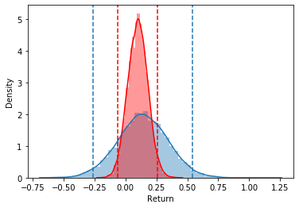

```python
mean_s1 = 0.14
sd_s1 = 0.2
stock1 = np.random.normal(mean, sd, 10000)

mean_s2 = 0.1
sd_s2 = 0.08
stock2 = np.random.normal(mean2, sd2, 10000)

sns.distplot(stock1, kde=True)
sns.distplot(stock2, kde=True, color = 'r')

plt.axvline(x=(mean_s1-2*sd_s1),ls='--')
plt.axvline(x=(mean_s1+2*sd_s1), ls='--')
plt.axvline(x=(mean_s2-2*sd_s2), color='r', ls='--')
plt.axvline(x=(mean_s2+2*sd_s2), color='r', ls='--')
plt.xlabel('Return')
plt.ylabel('Density')
plt.show()
```

You can see from the plot above that the high risk, high reward stock 1 (blue) has a much wider distribution because it has more variance. While a 50% return lies just within the 98% confidence interval for stock 1, so does a -25% return. Meanwhile, a majority of stock 3's distribution is in positive return area. The stock 3 distribution is much narrower, as well, indicating that we can more accurately predict how it will return for us.

### Correlation and Covariance

Everything above comes with one important caveat - stocks are not independent variables. We have to account for the correlation that takes place on the stock market - many stocks respond in kind to other stocks daily movements. Therefore, understanding the distribution of possible outcomes is not entirely dependent on a single stock's mean and variance. This in part can be described through correlation, which measures the strength of the relationship between two variables (closer to 1 being very correlated and near to 0 being highly non-correlated).

Another measure, which is very important to portfolio optimization, is covariance. Covariance measures the total variation of two random variables from their mean expected values. Covariance measures the relationship between two random variables, or to what extent they change together. Covariance is affected by the units in which the variables are measured.

Below, I have establised the correlation and covariance matrices.

```python
Corrs = [[1,0.6,0.4],
         [0.6,1,0.7],
         [0.4,0.7,1]]

covs = [[0.04, 0.018, 0.0064],
        [0.018,0.0225,0.0084],
        [0.0064,0.0084,0.0064]]
```

I created three variables to serve as the percentage of the initial investment that should be allocated to each stock.

```python
m.remove(m.getVars())
Inv_Weights = []
for i in range(len(MeanReturns)):
    Inv_Weights.append(m.addVar(vtype=GRB.CONTINUOUS, name = "Stock" + str(i), lb= 0.0))

print(m.getVars())
m.update()
```

```
[]
```

```python
m.setObjective(quicksum(Inv_Weights[i] * covs[i][j] * Inv_Weights[j] for i in range(len(Inv_Weights)) for j in range(len(Inv_Weights))), GRB.MINIMIZE)

m.update()
```

Below I am adding constraints to the optimization model. The first constraint mandates that the sum of the investment weights is equal to 1, i.e. 100% of your money is invested. The second constraint requires a minimum return of 0.12, ie a return of at least 12% on your investments.

```python
m.remove(m.getConstrs())

Req_return = 0.12

m.addConstr(quicksum(Inv_Weights), GRB.EQUAL, 1)
m.addConstr(quicksum(Inv_Weights[i] * MeanReturns[i] for i in range(len(MeanReturns))), GRB.GREATER_EQUAL,Req_return)

print(m.getConstrs())
m.update()
```

```
[]
```

```python
m.optimize()
```

```
Optimize a model with 2 rows, 3 columns and 6 nonzeros
Model has 6 quadratic objective terms
Coefficient statistics:
  Matrix range     [1e-01, 1e+00]
  Objective range  [0e+00, 0e+00]
  QObjective range [1e-02, 8e-02]
  Bounds range     [0e+00, 0e+00]
  RHS range        [1e-01, 1e+00]
Presolve time: 0.00s
Presolved: 2 rows, 3 columns, 6 nonzeros
Presolved model has 6 quadratic objective terms
Ordering time: 0.00s

Barrier statistics:
 Free vars  : 2
 AA' NZ     : 6.000e+00
 Factor NZ  : 1.000e+01
 Factor Ops : 3.000e+01 (less than 1 second per iteration)
 Threads    : 1

                  Objective                Residual
Iter       Primal          Dual         Primal    Dual     Compl     Time
   0   1.39490847e+05 -1.39490847e+05  2.50e+03 6.11e-06  1.00e+06     0s
   1   4.91553548e+03 -5.16907979e+03  1.49e+02 3.64e-07  6.17e+04     0s
   2   3.34728926e-02 -3.07903637e+02  1.50e-01 3.67e-10  1.39e+02     0s
   3   2.42930548e-02 -5.49077879e+01  1.50e-07 3.64e-16  1.37e+01     0s
   4   2.42829703e-02 -4.84595241e-02  4.87e-11 1.39e-17  1.82e-02     0s
   5   1.77774188e-02  1.23614009e-02  8.31e-13 2.78e-17  1.35e-03     0s
   6   1.49836017e-02  1.46915674e-02  1.67e-16 6.94e-18  7.30e-05     0s
   7   1.48024175e-02  1.47998880e-02  5.55e-16 6.75e-17  6.32e-07     0s
   8   1.48000024e-02  1.47999999e-02  2.44e-15 6.94e-18  6.32e-10     0s

Barrier solved model in 8 iterations and 0.02 seconds
Optimal objective 1.48000024e-02
```

```python
print(m.ObjVal)
```

```
0.014800002415706223
```